# Predicting MIAC Baseball Game Outcomes

May 2026

## What Is This Project?

> **Goal:** Build a model that predicts whether the **home team wins** a MIAC baseball game using only information available *before the first pitch.*

**Why does this matter?**

- Small-college baseball (DIII) is far less studied than professional or Division I analytics
- Home-field advantage at the DIII level is theoretically smaller, making it harder to isolate skill from noise
- The MIAC schedule is **short and weather-interrupted** — can rolling recent form capture team quality better than season averages?
- Practical value for coaches: lineup decisions, pitching deployment, tournament seed projections

## The Target Variable

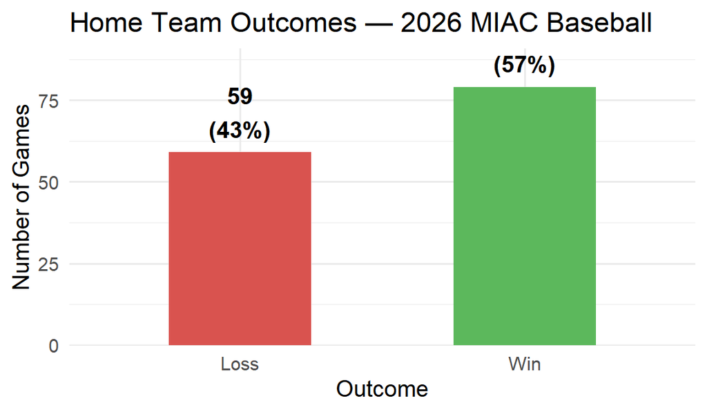

The home team won **57%** of completed games. A naive “always predict home win” baseline achieves only 57% accuracy — the model must do better.

## Variables Used (1/2) — Game Context & Recent Form

| Group | Variables | Why Important |
| --- | --- | --- |
| **Game context** | `is_conference`, `home_field` | Conference dynamics; crowd/travel advantage |
| **Rolling form (last 5)** | `rf_last5`, `ra_last5`, `win_last5`, `rd_last5` (home & away) | Short-term momentum and opponent quality |
| **Pitcher load (last 5)** | `sp_ip_last5`, `era_proxy_last5` (home & away) | Starter availability and recent effectiveness |

## Variables Used (2/2) — Season Statistics

| Group | Variables | Why Important |
| --- | --- | --- |
| **Away pitching (season)** | `era_season`, `whip_season`, `k_per9_season`, `bb_per9_season`, `opp_ba_season` | Stable baseline for team pitching quality |
| **Away fielding (season)** | `fld_pct_season`, `errors_season`, `dp_season`, `sba_season`, `csb_season` | Defensive efficiency |

> **Note:** Home season-level stats were **dropped** (>50% missing values) — a data asymmetry discussed later.

## Where Did the Data Come From?

**Source:** miacathletics.com — the official MIAC record-keeper

**How it was collected:**

1. Custom R web scraper using `rvest` + `chromote` (headless Chrome for JavaScript-rendered pages)
2. Scraped the **full composite schedule** (all months, Feb–May 2026)
3. Scraped **every box score** for every completed game
4. Scraped **team-level season stats** (pitching, batting, fielding)
5. Engineered **rolling (last-5-game) features** using a sliding window — *no future data leakage*

**Result:** 224 completed games scraped → **138 usable rows** after complete-case filtering

## Signal #1 — Recent Wins Matter

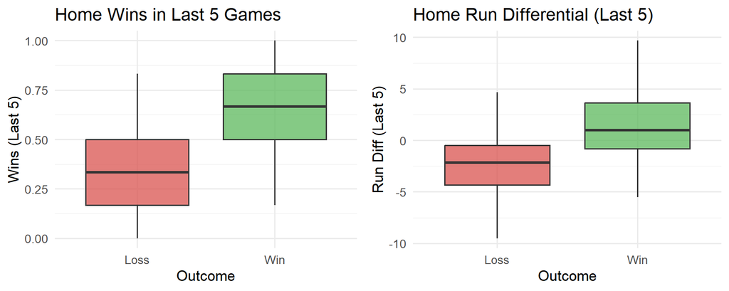

Teams with **more wins** and a **positive run differential** over their last 5 games are far more likely to win their next home game. Short-term momentum is the dominant signal.

## Signal #2 — Away ERA is Weaker Than Expected

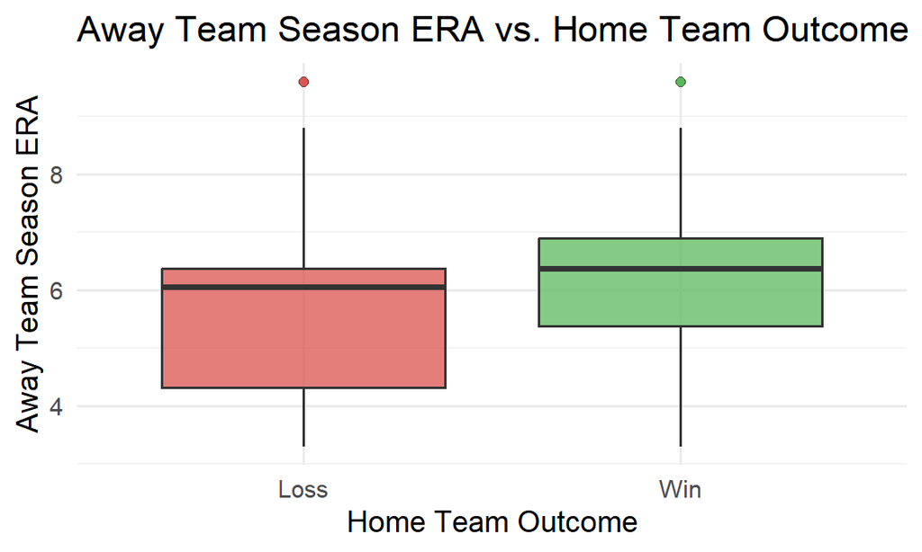

Away ERA shows only a **modest** separation — the MIAC is an offensive conference, and unearned runs (not captured in ERA) may shift outcomes without showing up in this stat.

## Design Decisions (1/2)

**Preventing data leakage** > All features computed strictly from information *prior* to each game. Scores and run differentials only appear in rolling windows ending *before* the target game.

**Handling missing data** > Home-team season-level stats exceeded **50% missing** and were dropped rather than imputed — imputing over half a column adds noise, not signal.

**Train/test split:** 80/20 random split — 110 training observations, 28 test observations (seed = 42).

## Design Decisions (2/2) — Three Model Types

| Model | Why |
| --- | --- |
| **Logistic Regression** | Interpretable baseline; well-suited to binary classification |
| **LASSO** | L1 regularization performs automatic feature selection; combats overfitting on small data |
| **Random Forest** | Captures nonlinear interactions; robust ensemble approach |

> Best Subset Selection returned a degenerate solution (0 selected variables) on this small sample — excluded from comparison.

## LASSO: Automatic Feature Selection

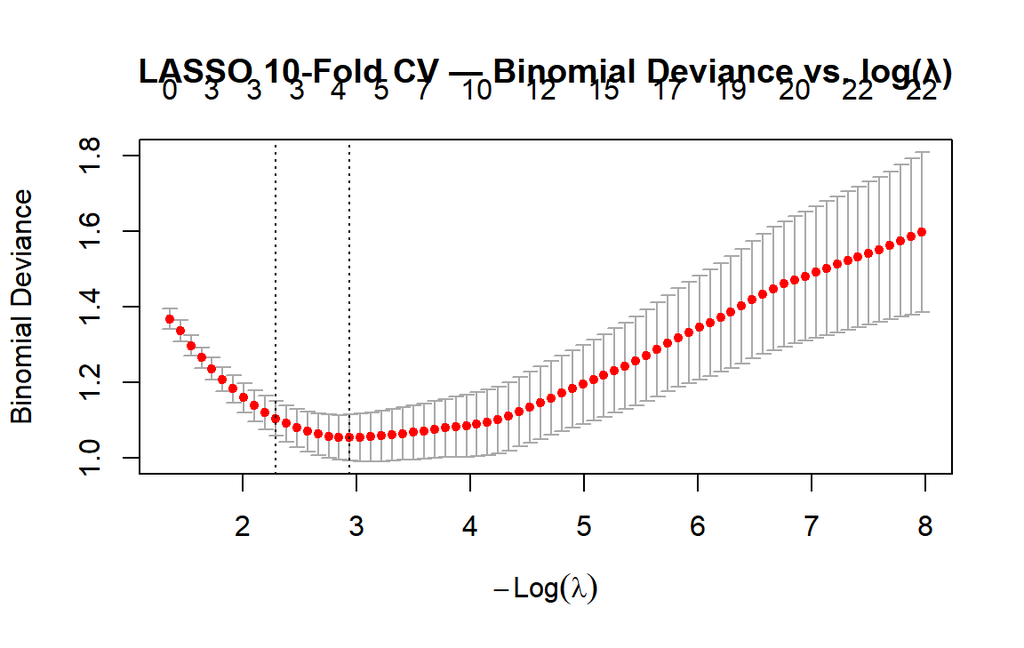

Using the **1-SE rule**, LASSO shrunk all but **3 predictors** to zero, avoiding overfitting.

## LASSO: The 3 Predictors That Survived

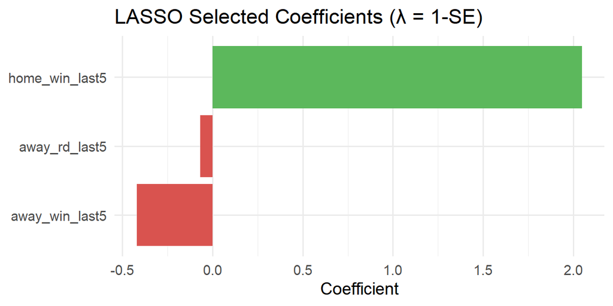

1. `home_win_last5` — Home team recent wins *(positive → more likely to win)*
2. `away_win_last5` — Away team recent wins *(negative → harder to beat good visitors)*
3. `away_rd_last5` — Away team run differential *(negative → strong visitor is a threat)*

## Random Forest: Variable Importance

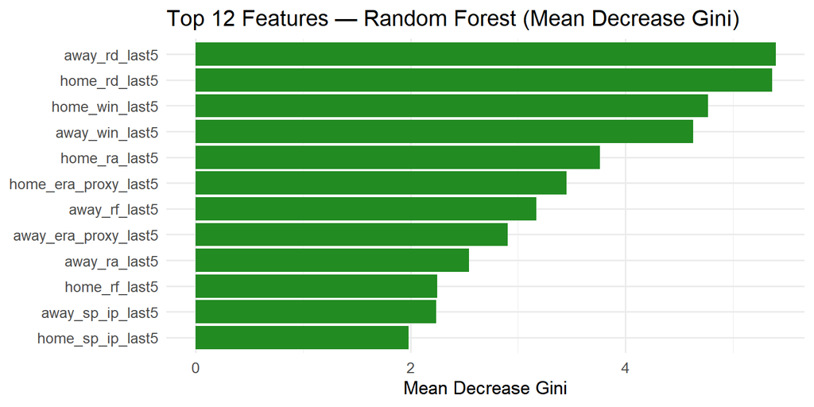

The Random Forest agrees: **recent run differential and wins** dominate. Season-level stats contribute far less — short-term momentum is the primary signal.

## Model Performance Comparison

| Model | Accuracy | AUC | Sensitivity | Specificity |
| --- | --- | --- | --- | --- |
| Logistic Regression | 0.750 | 0.795 | 0.733 | 0.769 |
| LASSO | 0.857 | 0.887 | 0.867 | 0.846 |
| Random Forest | 0.643 | 0.790 | 0.667 | 0.615 |

**LASSO wins on every metric** — 85.7% accuracy and AUC = 0.887 with only 3 features. The full logistic regression (26 features) is clearly overfitting the 110-observation training set.

## ROC Curve — Logistic Regression

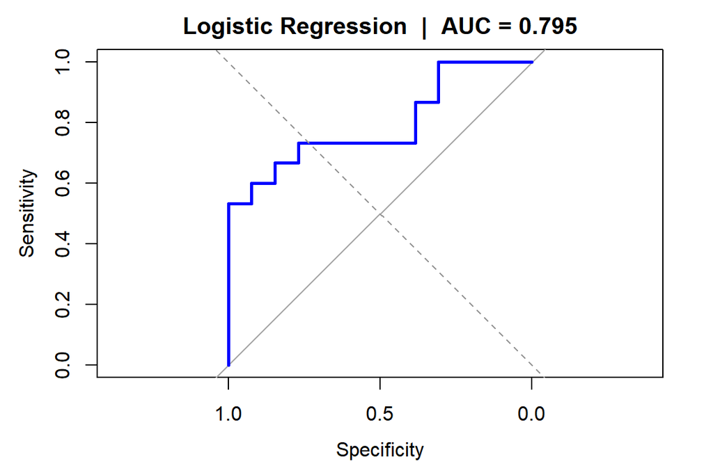

The curve shows how well the model ranks wins vs. losses at every threshold. AUC = 1.0 is perfect; AUC = 0.5 is a coin flip.

## ROC Curve — LASSO

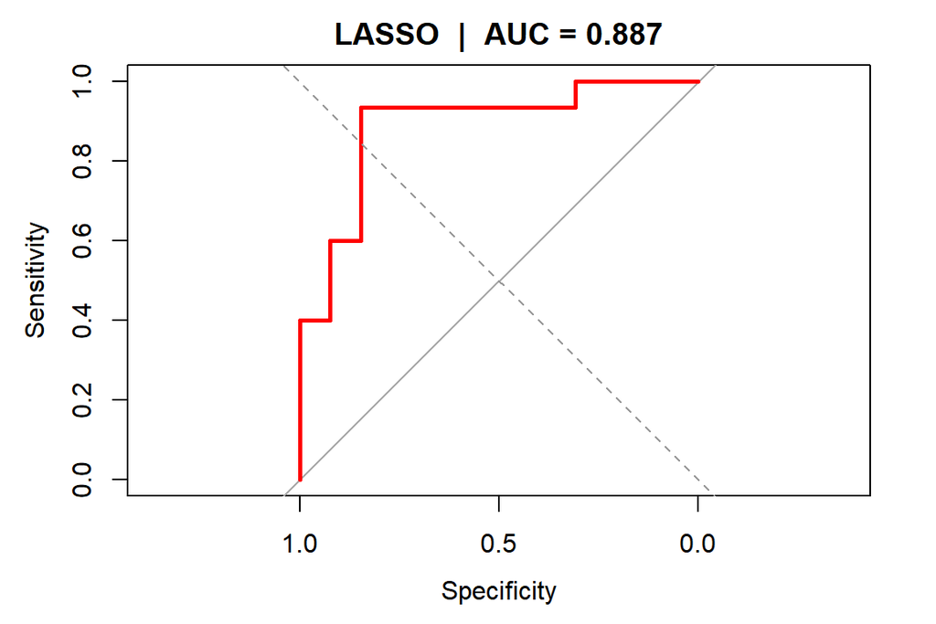

LASSO achieves the highest AUC with only **3 features**. The curve hugs the top-left corner — strong discrimination between wins and losses.

## ROC Curve — Random Forest

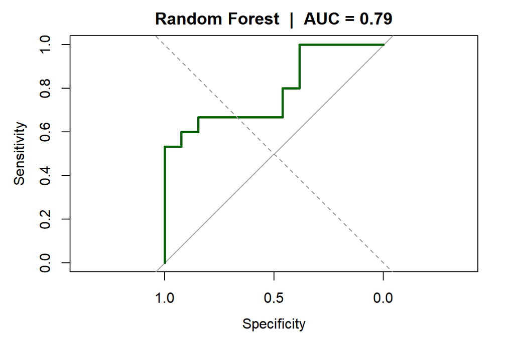

The Random Forest shows reasonable discrimination but trails LASSO, likely due to the small 28-game test set amplifying ensemble variance.

## Why Did LASSO Win? (Bias-Variance Tradeoff)

| Factor | What Happened |
| --- | --- |
| **Small dataset** (110 training obs.) | Complex models memorize noise; regularization protects against this |
| **26 predictors, 110 rows** | Logistic regression is underdetermined — coefficients are unreliable |
| **LASSO’s L1 penalty** | Forces most coefficients to zero, keeping only the 3 strongest signals |
| **Random Forest variance** | Ensemble variance is high with a 28-observation test set |

> **Key insight:** In this DIII short-season context, *recent form* is far more informative than long-run season statistics.

## What Could Make This Better?

**1. Multi-season data** — Training on 2023–2026 would grow the sample from ~138 to 500+ observations.

**2. Named starting pitcher** — Day-of-game starter ERA/WHIP is the strongest pre-game baseball signal; couldn’t get a consistent match at this dataset size.

**3. Head-to-head history** — Recent series results and rivalry effects carry signal beyond aggregate rolling stats.

**4. Weather & field conditions** — Temperature and wind affect scoring but are not currently included.

**5. Strength of schedule** — DIII talent gaps are enormous; no opponent-quality metric was available in this dataset.

## Key Takeaways

- **MIAC baseball outcomes are predictable** at a meaningfully above-chance level using only pre-game public data
- **LASSO with 3 features** outperformed models with 26 features — a textbook case of regularization beating complexity on small data
- **Short-term momentum** (wins and run differential over the last 5 games) is the dominant signal; season-long stats add little beyond it
- **Home-field advantage exists** (57% home win rate), but it is not the main driver of predictions
- **Primary limitation:** 138 usable games is a small sample — multi-season data is the single highest-impact improvement

> *“In short-season DIII baseball, what you did last week matters more than what you did all year.”*

## Thank You

**Data source:** MIAC Athletics — miacathletics.com

**Tools used:** R, `rvest`, `chromote`, `glmnet`, `randomForest`, `pROC`, `caret`, `ggplot2`

**Files:** - `MIAC_Full_Scrape.Rmd` — Web scraper - `Feature_Engineering_Final.Rmd` — Feature construction - `modeling.Rmd` — Model fitting - `Final_Report.rmd` — Full written report

> Questions?